[figure not shown]

# 瓦格纳 歌剧《特里斯坦与伊索尔德》

[咖喱学姊ciel](https://www.zhihu.com/people/ka-li-xue-zi-ciel)

舞蹈音乐表演

**崔斯坦和伊索尔德的故事，最早见于中世纪法兰西传奇，在历来的文学史研究中，都被归入骑士文学的范畴。**

据说这段爱情故事来源于古老的凯尔特传说，而这个传说是根据一位真实存在过的皮克特族国王的故事编纂的。可惜的是，传说的原始文本已经失传。

瓦格纳的这个音乐剧不论从故事结构还是人物关系，乃至悲剧根源及最终结局，都已偏离了法国中世纪骑士传奇的轨道。当遵循传统的法国人还在将这本传奇小册子置于枕边、反复诵读之时，我们长期以来只是不断地为德国的特里斯坦或者瓦格纳本人的遭遇唏嘘不已，抛洒热泪。

[figure not shown]

《**特利斯坦与伊索尔德**》（Tristan und Isolde）共三幕，第一幕的情节发生在浩瀚大海中独行的孤船上，特里斯坦奉康沃尔国王、自己的叔叔马克之命，接来了爱尔兰公主伊索尔德，公主将成为康沃尔王国的皇后，而特利斯坦与伊索尔德很早就已相识并相恋。此刻，一个青年水手正唱着一支壮丽的骊歌，船离康沃尔越来越近了，汹涌的大海是一对恋人激愤心情的象征，伊索尔德祈愿天神将船毁灭，于是，他们决定以毒药来结束这一切。然而，侍女布兰甘妮却以迷药代替了毒药，暗恋顿然化作了不可遏制的热恋，这对恋人的眼中闪烁着奇异的光辉，任何约束都不复存在了……

[figure not shown]

**特里斯坦与伊索尔德**  
**第二幕，暮色笼罩下的宫中花园**，马克国王同随行武士梅洛特打猎未归。昼尽夜至，疯狂的爱恋在夜的黑暗中激涨，伊索尔德不顾布兰甘妮的劝阻，来到花园同恋人私会。她按照约定熄灭了手中的火把，特里斯坦来了，一对被爱所点燃的情侣紧紧拥抱在一起，在黑暗中，一切都消失了，唯有极乐的幸福在闪烁。特利斯坦与伊索尔德的充满了狂喜和柔媚的、荡漾着情欲的、具有致命诱惑力的二重唱，使全剧达到了异常激动人心的高潮，**这支二重唱在“情死”的动机（即“伊索尔德的情死之歌”的旋律）出现之后开始：**  
啊，爱之夜，  
降临到我们身上吧，  
让我忘记生命的存在：  
让我进入你的心灵深处，  
自尘世间获得解脱！  
……  
神圣暮色的灿烂预感淹没了迷幻的恐惧，  
带给我们超凡的自由。  
……  
我的目光渐渐朦胧，  
黑暗中溢满狂喜，  
世界和它的空虚消褪远去……  
……  
我自己就是世界：  
生命中极乐的幸福，  
最圣洁的爱的灵魂，  
从未如此清醒，  
那自由的幻想，  
人所共有的甜蜜爱欲。  
……  
在热爱中销魂拥抱，  
彼此将一切奉献，  
生命唯有在我们的疯狂爱恋中存留！  
……  
啊，无尽的黑夜，  
甜蜜的黑夜！  
绚丽而圣洁的爱之夜！  
你带来抚爱，  
你带来微笑，  
当他们苏醒之时，  
怎能不为你而惊异？  
此刻已全无恐惧，  
热望着在狂爱中死去，  
那甜蜜的死亡！  
投入你的怀抱，  
献身于你，  
自不寐的痛苦之中，  
放射神圣而永恒的光芒！  
……  
远离阳光，  
远离白昼里分别的悲伤！  
……  
庄严地升华。  
……  
在甜蜜的黑夜里紧紧拥抱依偎。  
……  
在无际的宇空之中，  
不再分离，  
永结一体，  
唯一的爱人，  
最神圣的梦想！

……  
一个意念，  
无名的，  
不死的，  
才刚刚感受，  
才刚刚点燃，  
却永恒，  
却不息，  
那是爱的极乐在我们胸心焚燃！

在“情死”的动机中达到高潮，沉浸爱河的这对恋人忘记了时间，黑夜已渐逝，白昼已重现。他们的恋情被归来的马克国王发现，梅洛特的剑刺入了毫不躲避的特里斯坦的身体。

[figure not shown]

**第三幕，高崖上俯视苍茫大海的特里斯坦堡**，一棵菩提树下，濒死的特里斯坦正期待伊索尔德的到来。牧童吹奏着一支凄婉的悲歌，在昏迷与清醒之间，特里斯坦产生了幻觉，他大喊着：“船来了！船来了！”。……不知过了多久，他终于听到了他所渴念的熟悉的声音，他爬了起来，摇摇欲坠地奔向正张开双手朝他而来的伊索尔德，在伊索尔德的温柔怀抱中，特里斯坦注视着她，满怀内心的喜悦而死去。这时，马克国王得知迷药之情，宣布饶恕他们。此刻，伊索尔德凝视着死去的爱人，她心驰神摇，满怀情死的欢乐，“伊索尔德的情死之歌”轻轻地升起，慢慢地，注入了狂悦的激情：  
他的微笑多么温柔，  
多么平静！  
他张开双眼，  
多么天真无邪！  
你看到了吗，朋友？  
你没有见到吗？——  
他的光芒翱翔天际，  
令围绕他的灿烂群星黯然失色！  
难道你没有见到？——  
一颗骄傲、自豪、  
勇敢而完美的心在他的胸膛里搏动！  
他的柔唇颤动着甜蜜的气息——  
看哪，朋友！  
你没有感觉到？  
你没有看见？  
只有我听到了这悦耳的旋律吗？  
如此奇妙，  
如此亲切，  
在那极乐的悲哀中，  
坦荡的，  
温存而宽容的，  
发自他的声音，  
穿透了我，  
向上升飞，  
是神圣的回声在我的四周激荡吗？  
这回声愈加清晰响亮，  
令我随之飘扬，  
——它们是清爽的微风交织的海吗？  
它们是天空的芳香集结的云吗？  
它们在我的周围翻滚咆哮，  
——我呼吸着那微风、那芳香吗？  
我聆听着那海、那云吗？  
我将啜饮着微风和芳香  
投身到海和云的怀抱  
在甜蜜的芬芳中死去吗？  
在汹涌的浪涛间，  
在清脆响亮的回声里，  
在这尘世间茫茫的生命之海中——  
沉没了，  
沉入无知无觉之中——  
沉入极乐之中。

一曲终了，伊索尔德倒在特里斯坦的怀里，沉入到永恒的黑暗之中，也沉入到永恒的爱之夜中。

关于二人的名字，Tristan又写作Tristam或Tristrem，中译时往往根据不同的发音有着不同的译法，一般英文译作崔斯坦，法文称特里斯当，德文则称作托利斯坦。Isolde又写作Iseult、Isolt或Yseult，一般根据英文和德文中译作伊索尔德，法文则译作伊瑟或绮瑟。在托马斯·马罗礼氏的《亚瑟王之死》中译本中，译者将崔斯坦译作崔斯痛，伊索尔德译作绮秀·婉儿，大约是考虑到音义结合的关系。

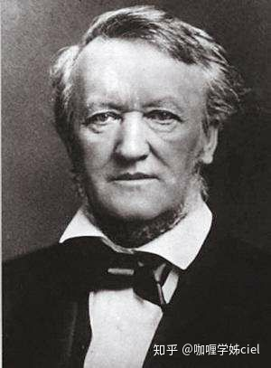

**瓦格纳本人**

崔斯坦和伊索尔德的故事被很多诗人、作家引用，或加以改写，有许多版本传世。可以确定的是，早在诺曼征服的时代，这对不朽恋人的传奇就已经广为流传，**女诗人玛丽·德·法兰西（Marie de France，创作年代大约在1160~1190年之间）写有一首著名的短诗《金银花》**，是我见到的关于这个故事最古老的文本。从这首诗中可以看出，当时的人们对崔斯坦和伊索尔德的故事已经相当熟悉。**12世纪末，英国还有一位知名的宫廷诗人托马斯·德·布列塔尼（Thomas de Brittany，生卒年不详）**，据传是亨利二世宫廷的盎格鲁-诺曼诗人，并且和他的主子一样，用法语进行写作。大约1170年左右，托马斯根据现存的传奇创作了叙事长诗《崔斯坦与伊索尔德》——我们有找到任何这部作品仍然存世的证据或暗示，然则这并不影响它的意义和价值。

**金银花原文**

*令我喜欢，我很乐意'*

*让你知道全部经过。*

*怎么产生，关于什么。*